# Spatio-temporal disease mapping with `R-INLA`

Julien Riou

2024-03-07

# 1 Spatio-temporal models in `R-INLA`

Lastly, we combine the spatial and temporal models that we learned to build spatio-temporal models. We continue to focus on reported influenza cases, now by canton over time.

```r
flu_week_canton = flu %>%
  filter(georegion_type=="canton", georegion!="unknown", agegroup=="all", sex=="all", type=="all") %>%
  mutate(week_of_season=lag(week_of_year,flu_season_start_week),
         week_of_season=ifelse(is.na(week_of_season),lead(week_of_season,52),week_of_season),
         week_of_season2=week_of_season,
         week_index2=week_index, # you have to repeat indexes as INLA doesn't allow the same variable twice
         canton_index=as.numeric(as.factor(georegion)),
         canton_index2=canton_index,
         year_index=year-2012,
         season_index=as.numeric(as.factor(season)))
```

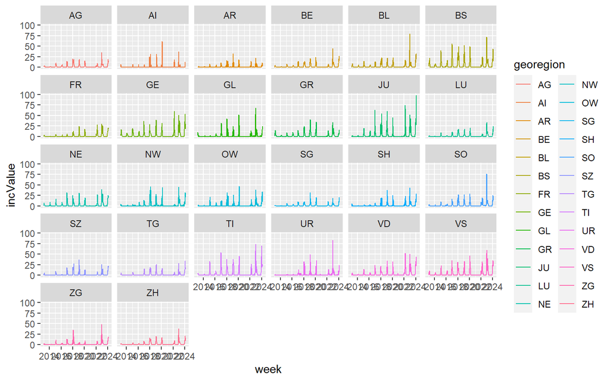

```r
ggplot(flu_week_canton,aes(x=week,y=incValue,colour=georegion)) +
  geom_line() +
  facet_wrap(~georegion)
```

## 1.1 I.i.d. spatio-temporal

One idea is to start from the temporal model (e.g. the one with seasonality), and just add one i.i.d. random effect that will scale the time series (again, the multiplicative effects come from the $\log$ link in Poisson regression).

```r
m_week_canton_ch1 = inla(value ~ 1 +
                           f(week_index, model="rw1", hyper=list(prec=list(param=c(1, 0.1))), constr=TRUE) +
                           f(week_of_year, model="rw1", hyper=list(prec=list(param=c(1, 0.1))), constr=TRUE) +
                           f(canton_index, model="iid", hyper=list(prec=list(param=c(1, 0.1))), constr=TRUE),
                         offset = log(pop),
                         data = flu_week_canton,
                         family = "poisson",
                         control.fixed = list(mean.intercept=0, prec.intercept=1/10^2),
                         control.compute = list(waic=TRUE))
summary(m_week_canton_ch1)
```

```
##
## Call:
##    c("inla.core(formula = formula, family = family, contrasts = contrasts,
##    ", " data = data, quantiles = quantiles, E = E, offset = offset, ", "
##    scale = scale, weights = weights, Ntrials = Ntrials, strata = strata,
##    ", " lp.scale = lp.scale, link.covariates = link.covariates, verbose =
##    verbose, ", " lincomb = lincomb, selection = selection, control.compute
##    = control.compute, ", " control.predictor = control.predictor,
##    control.family = control.family, ", " control.inla = control.inla,
##    control.fixed = control.fixed, ", " control.mode = control.mode,
##    control.expert = control.expert, ", " control.hazard = control.hazard,
##    control.lincomb = control.lincomb, ", " control.update =
##    control.update, control.lp.scale = control.lp.scale, ", "
##    control.pardiso = control.pardiso, only.hyperparam = only.hyperparam,
##    ", " inla.call = inla.call, inla.arg = inla.arg, num.threads =
##    num.threads, ", " keep = keep, working.directory = working.directory,
##    silent = silent, ", " inla.mode = inla.mode, safe = FALSE, debug =
##    debug, .parent.frame = .parent.frame)" )
## Time used:
##     Pre = 4.84, Running = 5.53, Post = 0.455, Total = 10.8
## Fixed effects:
##                mean    sd 0.025quant 0.5quant 0.975quant    mode kld
## (Intercept) -13.504 0.031    -13.565  -13.504    -13.444 -13.504   0
##
## Random effects:
##   Name     Model
##     week_index RW1 model
##    week_of_year RW1 model
##    canton_index IID model
##
## Model hyperparameters:
##                            mean    sd 0.025quant 0.5quant 0.975quant mode
## Precision for week_index   9.33 0.943       7.62     9.28      11.33 9.17
## Precision for week_of_year 9.07 2.040       5.57     8.89      13.55 8.62
## Precision for canton_index 5.62 1.537       3.09     5.46       9.09 5.17
##
## Watanabe-Akaike information criterion (WAIC) ...: 51397.68
## Effective number of parameters .................: 1771.86
##
## Marginal log-Likelihood:  -25644.49
##  is computed
## Posterior summaries for the linear predictor and the fitted values are computed
## (Posterior marginals needs also 'control.compute=list(return.marginals.predictor=TRUE)')
```

As always, we begin with a look at the model fit. For visibility we can focus on the first 4 cantons.

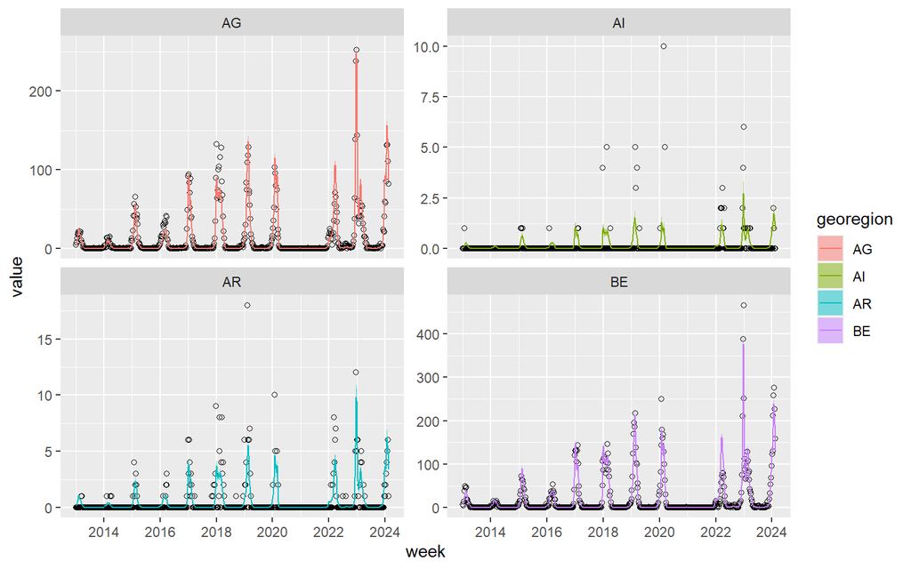

```r
m_week_canton_ch1$summary.fitted.values %>%
  bind_cols(flu_week_canton) %>%
  filter(canton_index<=4) %>%
  ggplot(aes(x=week)) +
  geom_point(aes(y=value), shape=21) +
  geom_ribbon(aes(ymin=`0.025quant`,ymax=`0.975quant`,fill=georegion),alpha=.5)  +
  geom_line(aes(y=mean,colour=georegion)) +
  facet_wrap(~georegion,scales="free_y")
```

The model appears to do what it’s supposed to: there is one unique temporal shape that is scaled upwards or downwards in each canton. Of course there are deviations in each canton (we will deal with them later), but the fit is not terrible, with the peaks and valleys more or less aligned, and the magnitude approximately well captured. We can look at the magnitude of the canton-specific scaling.

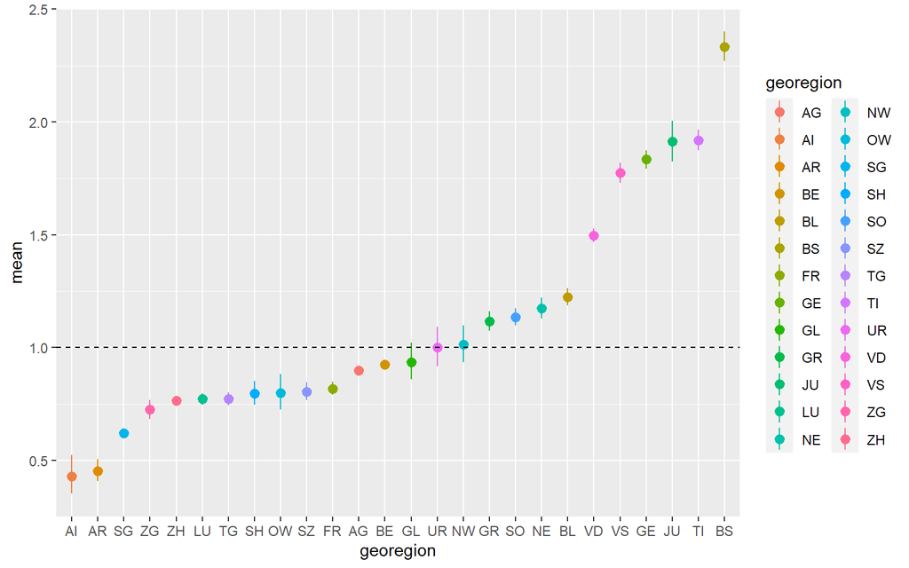

```r
temp_ = m_week_canton_ch1$summary.random$canton_index %>%
  select(canton_index=ID,mean,`0.025quant`,`0.975quant`) %>%
  mutate(across(2:4,exp)) %>%
  left_join(flu_week_canton %>% filter(year==2023) %>% select(canton_index,georegion) %>% distinct(),by = join_by(canton_index)) %>%
  arrange(mean)
ggplot(temp_,aes(x=georegion,y=mean,ymin=`0.025quant`,ymax=`0.975quant`,colour=georegion)) +
  geom_pointrange() +
  geom_hline(yintercept=1,linetype=2) +
  scale_x_discrete(limits=temp_$georegion)
```

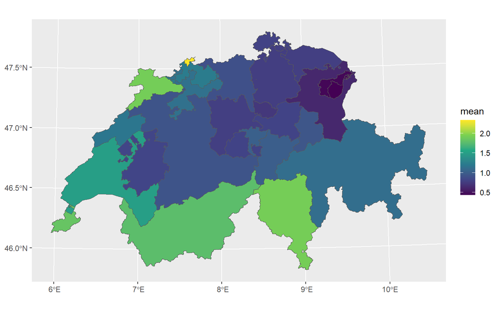

```r
shape_cantons %>%
  left_join(temp_,by = join_by(georegion)) %>%
  ggplot() +
  geom_sf(aes(fill=mean)) +
  scale_fill_viridis_c()
```

The results are similar but a bit different than back in file `4_space`, when we compared yearly totals across cantons in 2022 only. These are averaged over the whole period.

We can extend the approach to measure a cantonal effects for each year, in order to see whether these effects are systematic. For this we can use the `group` option, which allows to consider random effects stratified by some other variable. One limitation is that only indexes should be used for grouping (integers from 1 to N).

```r
m_week_canton_ch2 = inla(value ~ 1 +
                           f(week_index, model="rw1", hyper=list(prec=list(param=c(1, 0.1))), constr=TRUE) +
                           f(week_of_year, model="rw1", hyper=list(prec=list(param=c(1, 0.1))), constr=TRUE) +
                           f(canton_index, group=season_index, model="iid", hyper=list(prec=list(param=c(1, 0.1))), constr=TRUE),
                         offset = log(pop),
                         data = flu_week_canton,
                         family = "poisson",
                         control.fixed = list(mean.intercept=0, prec.intercept=1/10^2),
                         control.compute = list(waic=TRUE))
summary(m_week_canton_ch2)
```

```
##
## Call:
##    c("inla.core(formula = formula, family = family, contrasts = contrasts,
##    ", " data = data, quantiles = quantiles, E = E, offset = offset, ", "
##    scale = scale, weights = weights, Ntrials = Ntrials, strata = strata,
##    ", " lp.scale = lp.scale, link.covariates = link.covariates, verbose =
##    verbose, ", " lincomb = lincomb, selection = selection, control.compute
##    = control.compute, ", " control.predictor = control.predictor,
##    control.family = control.family, ", " control.inla = control.inla,
##    control.fixed = control.fixed, ", " control.mode = control.mode,
##    control.expert = control.expert, ", " control.hazard = control.hazard,
##    control.lincomb = control.lincomb, ", " control.update =
##    control.update, control.lp.scale = control.lp.scale, ", "
##    control.pardiso = control.pardiso, only.hyperparam = only.hyperparam,
##    ", " inla.call = inla.call, inla.arg = inla.arg, num.threads =
##    num.threads, ", " keep = keep, working.directory = working.directory,
##    silent = silent, ", " inla.mode = inla.mode, safe = FALSE, debug =
##    debug, .parent.frame = .parent.frame)" )
## Time used:
##     Pre = 4.02, Running = 18.2, Post = 0.542, Total = 22.7
## Fixed effects:
##                mean    sd 0.025quant 0.5quant 0.975quant    mode kld
## (Intercept) -13.641 0.033    -13.706  -13.641    -13.577 -13.641   0
##
## Random effects:
##   Name     Model
##     week_index RW1 model
##    week_of_year RW1 model
##    canton_index IID model
##
## Model hyperparameters:
##                             mean    sd 0.025quant 0.5quant 0.975quant  mode
## Precision for week_index   9.377 0.986       7.71    9.286     11.581 9.015
## Precision for week_of_year 9.148 2.139       5.83    8.855     14.189 8.223
## Precision for canton_index 2.527 0.432       1.76    2.498      3.459 2.452
## GroupRho for canton_index  0.575 0.073       0.43    0.576      0.716 0.574
##
## Watanabe-Akaike information criterion (WAIC) ...: 44169.60
## Effective number of parameters .................: 1987.86
##
## Marginal log-Likelihood:  -22050.08
##  is computed
## Posterior summaries for the linear predictor and the fitted values are computed
## (Posterior marginals needs also 'control.compute=list(return.marginals.predictor=TRUE)')
```

So now, while the shape of the time trend is the same in each canton, the canton-level scaling can now change from one year to the next. We can see whether there is an overall pattern.

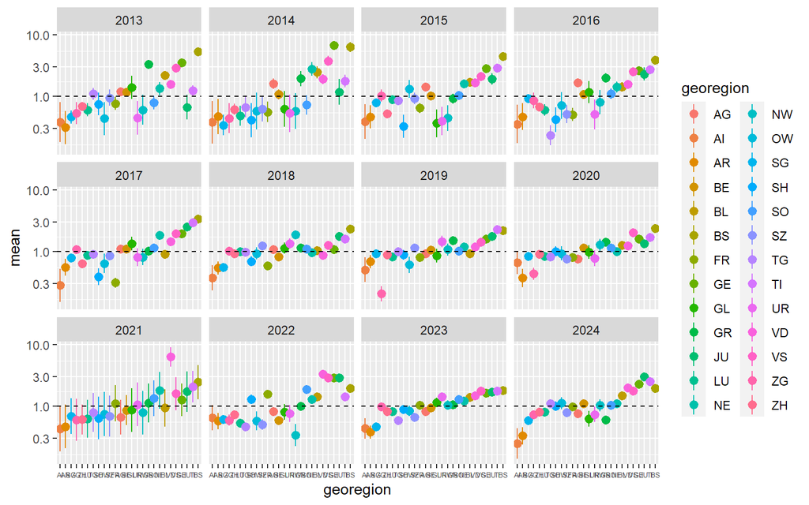

```r
temp_2 = m_week_canton_ch2$summary.random$canton_index %>%
  select(canton_index=ID,mean,`0.025quant`,`0.975quant`) %>%
  mutate(across(2:4,exp)) %>%
  left_join(flu_week_canton %>% filter(year==2023) %>% select(canton_index,georegion) %>% distinct(),by = join_by(canton_index)) %>%
  group_by(georegion) %>%
  mutate(year=row_number()+2012)
ggplot(temp_2,aes(x=georegion,y=mean,ymin=`0.025quant`,ymax=`0.975quant`,colour=georegion)) +
  geom_pointrange() +
  geom_hline(yintercept=1,linetype=2)  +
  scale_x_discrete(limits=temp_$georegion) +
  facet_wrap(~year) +
  scale_y_log10() +
  theme(axis.text.x = element_text(size=5))
```

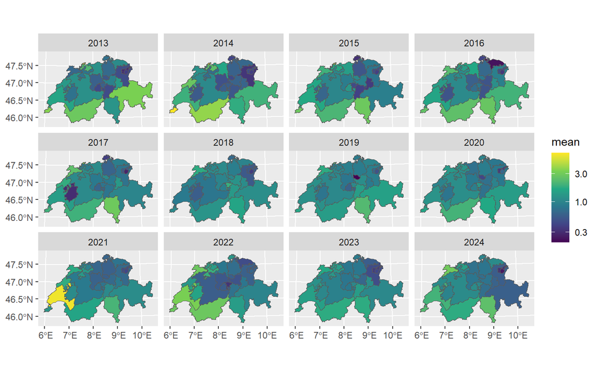

```r
shape_cantons %>%
  left_join(temp_2,by = join_by(georegion)) %>%
  ggplot() +
  geom_sf(aes(fill=mean)) +
  facet_wrap(~year) +
  scale_fill_viridis_c(trans="log10")
```

We do see some general patterns: the cantons with a highest and lowest IRRs are generally the same over the years.

We can now focus on cantonal level deviations from the national average.

```r
m_week_canton_ch3 = inla(value ~ 1 +
                           f(week_index, model="rw1", hyper=list(prec=list(param=c(1, 0.1))), constr=TRUE) +
                           f(week_of_year, model="rw1", hyper=list(prec=list(param=c(1, 0.1))), constr=TRUE) +
                           f(canton_index,model="iid", hyper=list(prec=list(param=c(1, 0.1))), constr=TRUE) +
                           f(week_index2, model="rw1", group=canton_index2, hyper=list(prec=list(param=c(1, 0.1))), constr=TRUE),
                         offset = log(pop),
                         data = flu_week_canton,
                         family = "poisson",
                         num.threads = 4,
                         control.fixed = list(mean.intercept=0, prec.intercept=1/10^2),
                         control.compute = list(waic=TRUE))
summary(m_week_canton_ch3)
```

```
##
## Call:
##    c("inla.core(formula = formula, family = family, contrasts = contrasts,
##    ", " data = data, quantiles = quantiles, E = E, offset = offset, ", "
##    scale = scale, weights = weights, Ntrials = Ntrials, strata = strata,
##    ", " lp.scale = lp.scale, link.covariates = link.covariates, verbose =
##    verbose, ", " lincomb = lincomb, selection = selection, control.compute
##    = control.compute, ", " control.predictor = control.predictor,
##    control.family = control.family, ", " control.inla = control.inla,
##    control.fixed = control.fixed, ", " control.mode = control.mode,
##    control.expert = control.expert, ", " control.hazard = control.hazard,
##    control.lincomb = control.lincomb, ", " control.update =
##    control.update, control.lp.scale = control.lp.scale, ", "
##    control.pardiso = control.pardiso, only.hyperparam = only.hyperparam,
##    ", " inla.call = inla.call, inla.arg = inla.arg, num.threads =
##    num.threads, ", " keep = keep, working.directory = working.directory,
##    silent = silent, ", " inla.mode = inla.mode, safe = FALSE, debug =
##    debug, .parent.frame = .parent.frame)" )
## Time used:
##     Pre = 3.29, Running = 501, Post = 1.68, Total = 506
## Fixed effects:
##                mean   sd 0.025quant 0.5quant 0.975quant    mode kld
## (Intercept) -13.868 0.04    -13.946  -13.868     -13.79 -13.868   0
##
## Random effects:
##   Name     Model
##     week_index RW1 model
##    week_of_year RW1 model
##    canton_index IID model
##    week_index2 RW1 model
##
## Model hyperparameters:
##                              mean    sd 0.025quant 0.5quant 0.975quant  mode
## Precision for week_index    9.684 1.366      6.938    9.701      12.22 10.05
## Precision for week_of_year  8.780 1.928      5.587    8.578      13.14  8.19
## Precision for canton_index  3.918 0.834      2.485    3.847       5.75  3.73
## Precision for week_index2  17.226 3.030     13.148   16.656      24.77 14.93
## GroupRho for week_index2    0.028 0.080     -0.039   -0.005       0.25 -0.04
##
## Watanabe-Akaike information criterion (WAIC) ...: 33440.89
## Effective number of parameters .................: 2144.09
##
## Marginal log-Likelihood:  -18372.30
##  is computed
## Posterior summaries for the linear predictor and the fitted values are computed
## (Posterior marginals needs also 'control.compute=list(return.marginals.predictor=TRUE)')
```

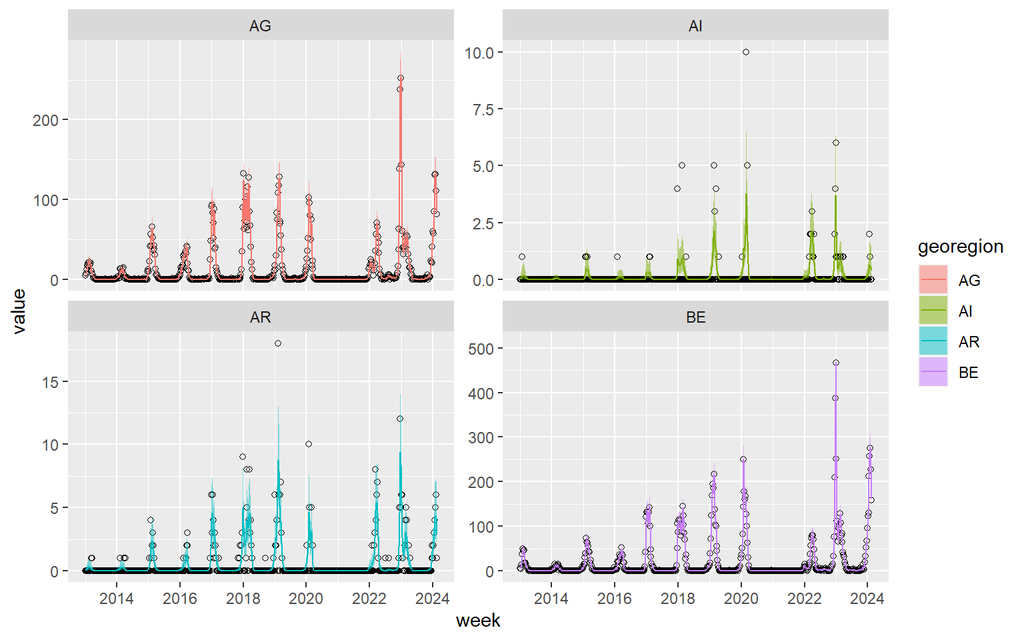

```r
m_week_canton_ch3$summary.fitted.values %>%
  bind_cols(flu_week_canton) %>%
  filter(canton_index<=4) %>%
  ggplot(aes(x=week)) +
  geom_point(aes(y=value), shape=21) +
  geom_ribbon(aes(ymin=`0.025quant`,ymax=`0.975quant`,fill=georegion),alpha=.5)  +
  geom_line(aes(y=mean,colour=georegion)) +
  facet_wrap(~georegion,scales="free_y")
```

This residual effect captures outliers, so that the estimation of the canton-specific effects should be more reliable.

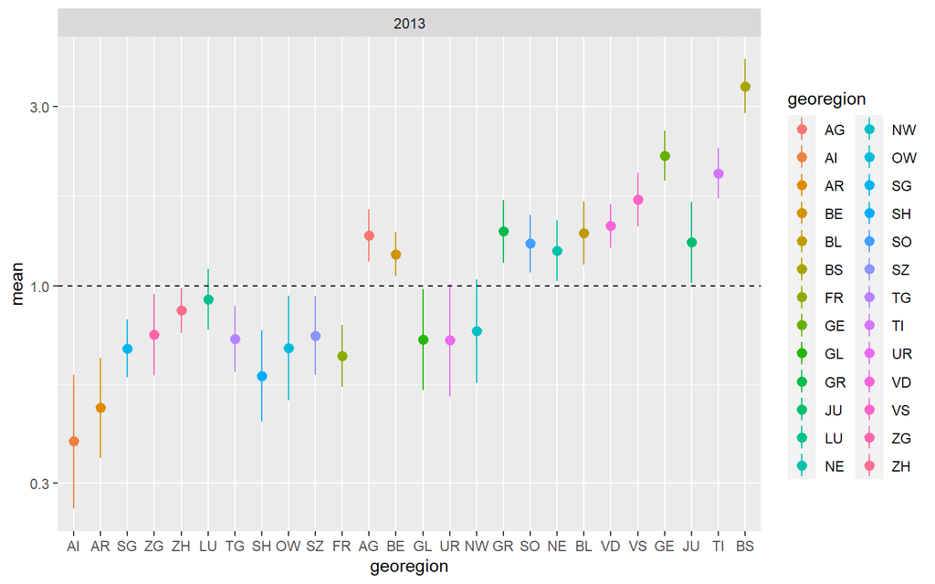

```r
temp_3 = m_week_canton_ch3$summary.random$canton_index %>%
  select(canton_index=ID,mean,`0.025quant`,`0.975quant`) %>%
  mutate(across(2:4,exp)) %>%
  left_join(flu_week_canton %>% filter(year==2023) %>% select(canton_index,georegion) %>% distinct(),by = join_by(canton_index)) %>%
  group_by(georegion) %>%
  mutate(year=row_number()+2012)
ggplot(temp_3,aes(x=georegion,y=mean,ymin=`0.025quant`,ymax=`0.975quant`,colour=georegion)) +
  geom_pointrange() +
  geom_hline(yintercept=1,linetype=2)  +
  scale_x_discrete(limits=temp_$georegion) +
  facet_wrap(~year) +
  scale_y_log10()
```

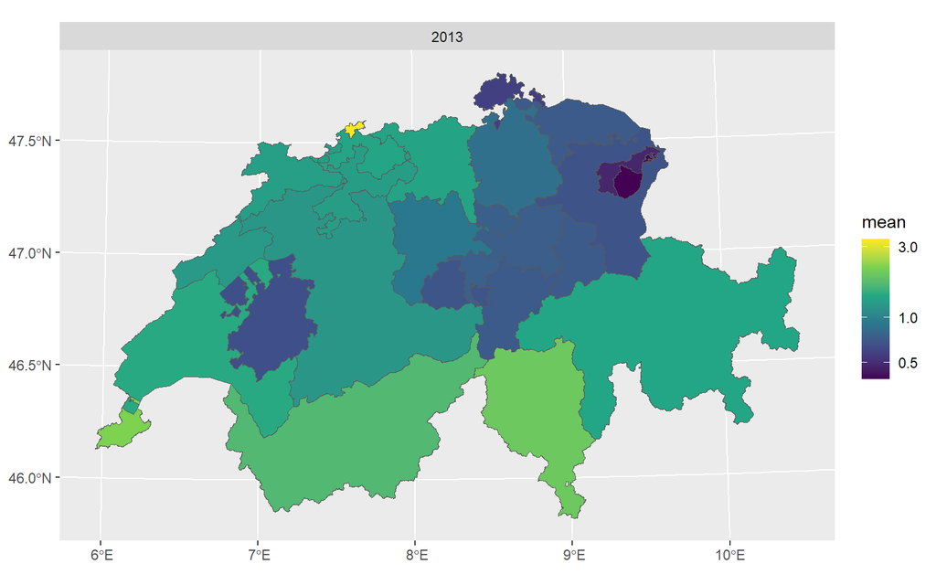

```r
shape_cantons %>%
  left_join(temp_3,by = join_by(georegion)) %>%
  ggplot() +
  geom_sf(aes(fill=mean)) +
  facet_wrap(~year) +
  scale_fill_viridis_c(trans="log10")
```

## 1.2 Exercise

Of course, one piece is still missing. We’ve been considering i.i.d. random effects by canton, but what we really want is to account for the spatial structure of cantons. This is the final exercise: consider the canton-specific effects within a BYM spatio-temporal model. You can start from model `m_week_canton_ch1`, but feel free to explore other options (`rw2`, `ar1`, `group`…). It can also help to compare models with WAIC. One possible approach is commented out in the `.Rmd` version of this script.

# 2 References